# Project Writeup

Felipe Navarrete

Sunday, September 21, 2014

Loading the necessary libraries

```r
library(rpart)
library(randomForest)
library(caret)
library(e1071)
```

Setting the working directory. IT HAS TO BE CHANGED TO THE FOLDER WHERE THE DATA IS STORED (otherwise the script cannot run)

```r
setwd("C:/COURSERA/2014/PracticalMachineLearning/ProjectWriteup")
```

The training and testing data sets are read

```r
training <- read.csv("pml-training.csv",header=TRUE,stringsAsFactors=FALSE)
testing <- read.csv("pml-testing.csv",header=TRUE,stringsAsFactors=FALSE)
```

The training dataset is splitted in training (60% of the data) and validation (40% of the data) sets.

```r
inTrain <- createDataPartition(y=training$classe,p=0.6,list=FALSE)

training <- training[inTrain,]
validation <- training[-inTrain,]
```

The data classe classifier is plotted against index. It is clear the step-like pattern, which could be indicative of a missing feature.

```r
length(training$classe)
```

```
## [1] 11776
```

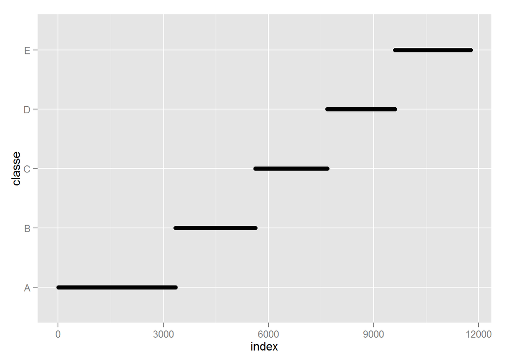

```r
index <- seq(1,length(training$classe))
qplot(index,classe,data=training,na.rm=TRUE)
```

We check if this correlated with the user name by using a color code for each name. We see that that is not the case

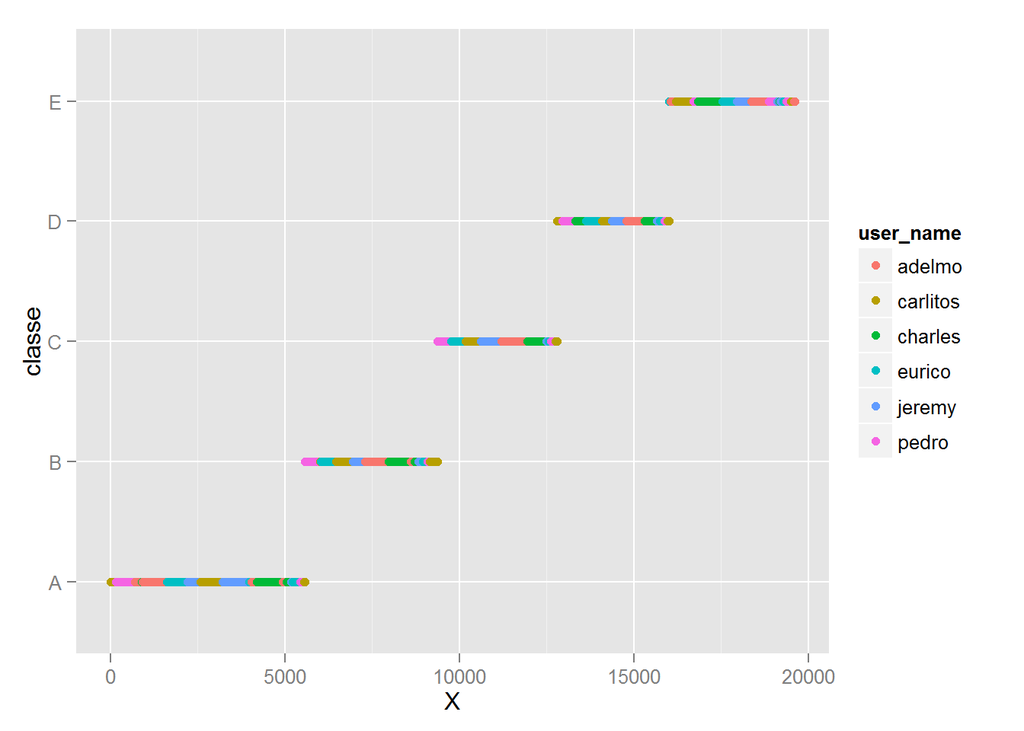

The data has to be pre-processed before having fun. The first obvious thing that pops-out from the data is that there are a lot of features, and that many of these features have values NA

```r
head(training,n=15)
```

```
##     X user_name raw_timestamp_part_1 raw_timestamp_part_2   cvtd_timestamp
## 1   1  carlitos           1323084231               788290 05/12/2011 11:23
## 2   2  carlitos           1323084231               808298 05/12/2011 11:23
## 3   3  carlitos           1323084231               820366 05/12/2011 11:23
## 6   6  carlitos           1323084232               304277 05/12/2011 11:23
## 7   7  carlitos           1323084232               368296 05/12/2011 11:23
## 11 11  carlitos           1323084232               500302 05/12/2011 11:23
## 12 12  carlitos           1323084232               528316 05/12/2011 11:23
## 14 14  carlitos           1323084232               576390 05/12/2011 11:23
## 15 15  carlitos           1323084232               604281 05/12/2011 11:23
## 16 16  carlitos           1323084232               644302 05/12/2011 11:23
## 17 17  carlitos           1323084232               692324 05/12/2011 11:23
## 19 19  carlitos           1323084232               740353 05/12/2011 11:23
## 20 20  carlitos           1323084232               788335 05/12/2011 11:23
## 21 21  carlitos           1323084232               876301 05/12/2011 11:23
```

[output cut: 641 more lines]

I iterate over all the variables to find out which are mainly composed of NA values (> 50%)and remove them. Also I have checked in the variables of type ‘character’ the empty entries, i.e, ’’. If more than 50% of the values are empty entries, the feature is removed from the final sample.

```r
ratio <- double()
keeps <- character()
count=1

for (i in names(training)) {
    new <- is.na(training[[i]])
    newratio = (length(training$X[new]))/(length(training[[i]]))
    ratio <- c(ratio,newratio)
    if (newratio <= 0.5 && typeof(training[[i]]) != 'character'){
        newkeep = i
        keeps <- c(keeps,newkeep)
    }
    if (typeof(training[[i]]) == 'character'){
        num_empty = sum(training[[i]] == '')
        newratio = num_empty/(length(training[[i]]))
        if (newratio <= 0.5){
            newkeep = i
            keeps <- c(keeps,newkeep)
        }
     }
    count=count+1
}
```

```r
training2 <- training[keeps]
validation2 <- validation[keeps]
testing2 <- testing[keeps[-60]]
```

Identifying the type of each feature in the data

```r
var <- sapply(training2,class)
```

We remove some features that we do not consider will be important in order to classify the exercise, e.g., X, user_name, etc.

```r
var2 = which(var == 'character')

training3 <- training2[,-var2]
validation3 <- validation2[,-var2]
testing3 <- testing2[,-var2[-4]]

subset <-  c(names(training3),names(training2)[60])

training4 <- training2[subset]
training4 <- training4[,5:57]
validation4 <- validation2[subset]
validation4 <- validation4[,5:57]
testing4 <- testing2[subset[-57]]
testing4 <- testing4[,5:56]
```

We try to identify those variables that have near zero variance in order to remove them

```r
nsv <- nearZeroVar(training4,saveMetrics=TRUE)
nsv
```

```
##                      freqRatio percentUnique zeroVar   nzv
## roll_belt                1.104       8.66168   FALSE FALSE
## pitch_belt               1.069      13.79925   FALSE FALSE
## yaw_belt                 1.054      14.42765   FALSE FALSE
## total_accel_belt         1.109       0.23777   FALSE FALSE
## gyros_belt_x             1.059       1.06148   FALSE FALSE
## gyros_belt_y             1.193       0.55197   FALSE FALSE
## gyros_belt_z             1.122       1.33322   FALSE FALSE
## accel_belt_x             1.012       1.34171   FALSE FALSE
## accel_belt_y             1.094       1.16338   FALSE FALSE
## accel_belt_z             1.049       2.40319   FALSE FALSE
## magnet_belt_x            1.071       2.51359   FALSE FALSE
## magnet_belt_y            1.078       2.40319   FALSE FALSE
## magnet_belt_z            1.076       3.60904   FALSE FALSE
## roll_arm                45.022      19.45482   FALSE FALSE
## pitch_arm               77.923      22.52038   FALSE FALSE
## yaw_arm                 31.656      21.39946   FALSE FALSE
## total_accel_arm          1.050       0.55197   FALSE FALSE
## gyros_arm_x              1.025       5.27344   FALSE FALSE
## gyros_arm_y              1.454       3.05707   FALSE FALSE
## gyros_arm_z              1.150       1.99558   FALSE FALSE
## accel_arm_x              1.108       6.36889   FALSE FALSE
## accel_arm_y              1.205       4.44124   FALSE FALSE
## accel_arm_z              1.037       6.40285   FALSE FALSE
## magnet_arm_x             1.093      11.12432   FALSE FALSE
## magnet_arm_y             1.038       7.20109   FALSE FALSE
## magnet_arm_z             1.000      10.53838   FALSE FALSE
## roll_dumbbell            1.013      87.51698   FALSE FALSE
## pitch_dumbbell           2.513      85.07133   FALSE FALSE
## yaw_dumbbell             1.000      85.01189   FALSE FALSE
## total_accel_dumbbell     1.062       0.33967   FALSE FALSE
## gyros_dumbbell_x         1.005       1.95312   FALSE FALSE
## gyros_dumbbell_y         1.319       2.24185   FALSE FALSE
## gyros_dumbbell_z         1.128       1.58798   FALSE FALSE
## accel_dumbbell_x         1.049       3.44769   FALSE FALSE
## accel_dumbbell_y         1.026       3.82133   FALSE FALSE
## accel_dumbbell_z         1.113       3.32880   FALSE FALSE
## magnet_dumbbell_x        1.131       8.98438   FALSE FALSE
## magnet_dumbbell_y        1.136       6.92935   FALSE FALSE
## magnet_dumbbell_z        1.009       5.61311   FALSE FALSE
## roll_forearm            10.990      14.68240   FALSE FALSE
## pitch_forearm           65.571      21.08526   FALSE FALSE
## yaw_forearm             14.434      14.12194   FALSE FALSE
## total_accel_forearm      1.163       0.56046   FALSE FALSE
## gyros_forearm_x          1.015       2.28431   FALSE FALSE
## gyros_forearm_y          1.052       5.99524   FALSE FALSE
## gyros_forearm_z          1.105       2.41168   FALSE FALSE
## accel_forearm_x          1.138       6.54721   FALSE FALSE
## accel_forearm_y          1.161       8.15217   FALSE FALSE
## accel_forearm_z          1.010       4.67901   FALSE FALSE
## magnet_forearm_x         1.083      12.05842   FALSE FALSE
## magnet_forearm_y         1.216      15.21739   FALSE FALSE
## magnet_forearm_z         1.000      13.31522   FALSE FALSE
## classe                   1.469       0.04246   FALSE FALSE
```

None of the remaining features falls in the near zero variance class, so nothing is removed at this step.

We check how correlated are the remaining variables

```r
M <- abs(cor(training4[-53]))
```

The terms of the diagonal are set to zero as the correlation of a variable with itself is 1

```r
diag(M) <- 0
```

We check all the variables that have a correlation values greater than 0.8

```r
which(M > 0.8,arr.ind=T)
```

```
##                  row col
## yaw_belt           3   1
## total_accel_belt   4   1
## accel_belt_y       9   1
## accel_belt_z      10   1
## accel_belt_x       8   2
## magnet_belt_x     11   2
## roll_belt          1   3
## roll_belt          1   4
## accel_belt_y       9   4
## accel_belt_z      10   4
## pitch_belt         2   8
## magnet_belt_x     11   8
## roll_belt          1   9
## total_accel_belt   4   9
## accel_belt_z      10   9
## roll_belt          1  10
## total_accel_belt   4  10
## accel_belt_y       9  10
## pitch_belt         2  11
## accel_belt_x       8  11
## gyros_arm_y       19  18
## gyros_arm_x       18  19
## magnet_arm_x      24  21
## accel_arm_x       21  24
## magnet_arm_z      26  25
## magnet_arm_y      25  26
## accel_dumbbell_x  34  28
## accel_dumbbell_z  36  29
## pitch_dumbbell    28  34
## yaw_dumbbell      29  36
```

This is how it looks a scatter plot of two variables highly correlated.

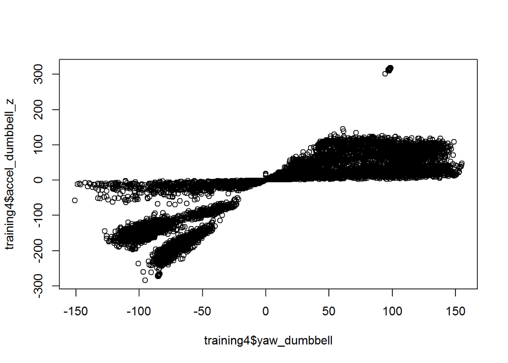

before fitting a model we convert the ‘classe’ variable to a factor type

```r
training4$classe <- as.factor(training4$classe)
validation4$classe <- as.factor(validation4$classe)
fitControl <- trainControl(repeats = 5)
```

As there are many variables that have a high correlation the data is pre-processed with the principal component analysis method.

```r
preProc <- preProcess(training4[,-53],method='pca',thresh=0.8)
preProc
```

```
##
## Call:
## preProcess.default(x = training4[, -53], method = "pca", thresh = 0.8)
##
## Created from 11776 samples and 52 variables
## Pre-processing: principal component signal extraction, scaled, centered
##
## PCA needed 13 components to capture 80 percent of the variance
```

The found solution is applied to the training, validation, and test sets.

```r
trainPC <- predict(preProc,training4[-53])
validationPC <- predict(preProc,validation4[-53])
testingPC <- predict(preProc,testing4)
```

Finally the training set is modeled with the random forest method. The training set is bootstrapped 25 times in order to cross validate and average the errors.

```r
modelFit <- train(training4$classe ~ .,method='rf',data=trainPC,trControl=fitControl)
modelFit
```

[output not shown]

We obtain a high accuracy ~ 92%

The prediction is computed on the validation set.

```r
mod_pred <- predict(modelFit,validationPC)
ind <- mod_pred == validation4$classe
length(which(ind))/length(mod_pred)
```

```
## [1] 1
```

Finally, the prediction for the test data set are computed and submitted.

```r
test_prediction <- predict(modelFit,testingPC)
```